# Estimating Nonlinear Trajectories for Longitudinal Data

Zheyuan Li

2022-10-19

```r
library(psplwork)  ## remotes::install_github("ZheyuanLi/psplwork")
library(mgcv)
```

```r
library(ggplot2)
library(gridExtra)
library(gratia)
```

# 1 Data example

You can access the data via function `getBMI100`.

```r
head(mbmi100 <- getBMI100("M"))
```

```
##          age      bmi   id       lage
## 1 0.09329162 13.58572 M001 -2.3720250
## 2 0.17268363 15.38245 M001 -1.7562941
## 3 0.24609857 15.33981 M001 -1.4020231
## 4 0.34023873 16.20743 M001 -1.0781078
## 5 0.40999551 15.90694 M001 -0.8916091
## 6 0.50694408 16.95482 M001 -0.6793546
```

```r
head(fbmi100 <- getBMI100("M"))
```

```
##          age      bmi   id       lage
## 1 0.09329162 13.58572 M001 -2.3720250
## 2 0.17268363 15.38245 M001 -1.7562941
## 3 0.24609857 15.33981 M001 -1.4020231
## 4 0.34023873 16.20743 M001 -1.0781078
## 5 0.40999551 15.90694 M001 -0.8916091
## 6 0.50694408 16.95482 M001 -0.6793546
```

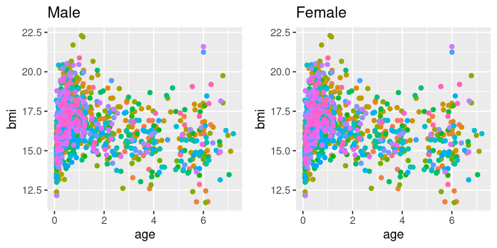

```r
M.plot <- ggplot(data = mbmi100, mapping = aes(x = age, y = bmi)) +
  geom_point(mapping = aes(color = id), show.legend = FALSE) +
  ggtitle("Male")

F.plot <- ggplot(data = fbmi100, mapping = aes(x = age, y = bmi)) +
  geom_point(mapping = aes(color = id), show.legend = FALSE) +
  ggtitle("Female")

grid.arrange(M.plot, F.plot, nrow = 1, ncol = 2)
```

# 2 A separate model for each sex group

## 2.1 A general statistical model

The observation $y_{it}$ for subject $i$ at time $t$:

$$\begin{equation*}
y_{it} = f(t) + r_i(t) + e_{it},
\end{equation*}$$

- $f(t)$, the population trajectory;
- $r_i(t)$, the deviation of subject $i$’s trajectory from $f(t)$.

## 2.2 Model specification in mgcv

The population trajectory $f(t)$ is specified as:

```r
s(t, bs = "ps", k = ?, m = c(2, 2))
```

- `t`, the name (to be substituted) of the time variable.
- `bs`, type of spline basis; “ps” for P-splines.
- `k`, the number of basis functions used to express each random curve; for “ps”, it is the number of B-splines.
- `m`, penalty information. `c(2, 2)` for cubic B-splines penalized by 2nd order differences.

The subject-specific deviation trajectory $r_i(t)$ is specified as:

```r
s(t, i, bs = "fs", xt = "ps", k = ?, m = c(2, 1))
```

- `t`, the name (to be substituted) of the time variable.
- `i`, the name (to be substituted) of the subject ID variable; must be provided as a factor .
- `"fs"`, the proper way for setting up random curves.
- `xt` (short for “extra”), used to specify the spline basis for each random curve.
- `k`, the number of basis functions used to express each random curve; for “ps”, it is the number of B-splines.
- `m`, penalty information. `c(2, 1)` for cubic B-splines penalized by 1nd order differences.

## 2.3 Model fitting in mgcv

In this context, the mgcv model formula is:

```r
form <- bmi ~ s(lage, bs = 'ps', k = 10, m = c(2, 2)) +
  s(lage, id, bs = "fs", xt = "ps", k = 10, m = c(2, 1))
```

We fit this model using `mgcv::gamm()` or `gamm4::gamm4()`, not `mgcv::gam()` or `mgcv::bam()`.

```r
fit <- gamm(form, data = mbmi100)
```

## 2.4 Covariate grids

For prediction purpose.

```r
age.grid <- seq(min(mbmi100$age), max(mbmi100$age), length.out = 100)
id.grid <- factor(levels(mbmi100$id), levels(mbmi100$id))
```

## 2.5 Predict and plot all subject trajectories

Easy to do; just use `predict` to predict the response variable.

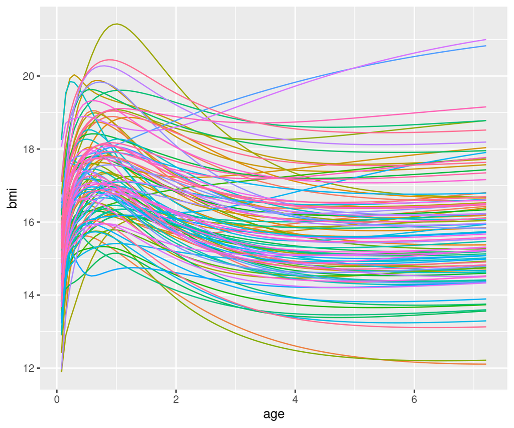

```r
## a data.frame
subtraj <- expand.grid(age = age.grid, id = id.grid)
subtraj$lage <- log(age.grid)
## add predicted values to data.frame
subtraj$bmi <- predict(fit$gam, newdata = subtraj)
## plot
ggplot(data = subtraj, mapping = aes(age, bmi)) +
  geom_line(mapping = aes(color = id), show.legend = FALSE)
```

## 2.6 Plot trajectories for a few subjects

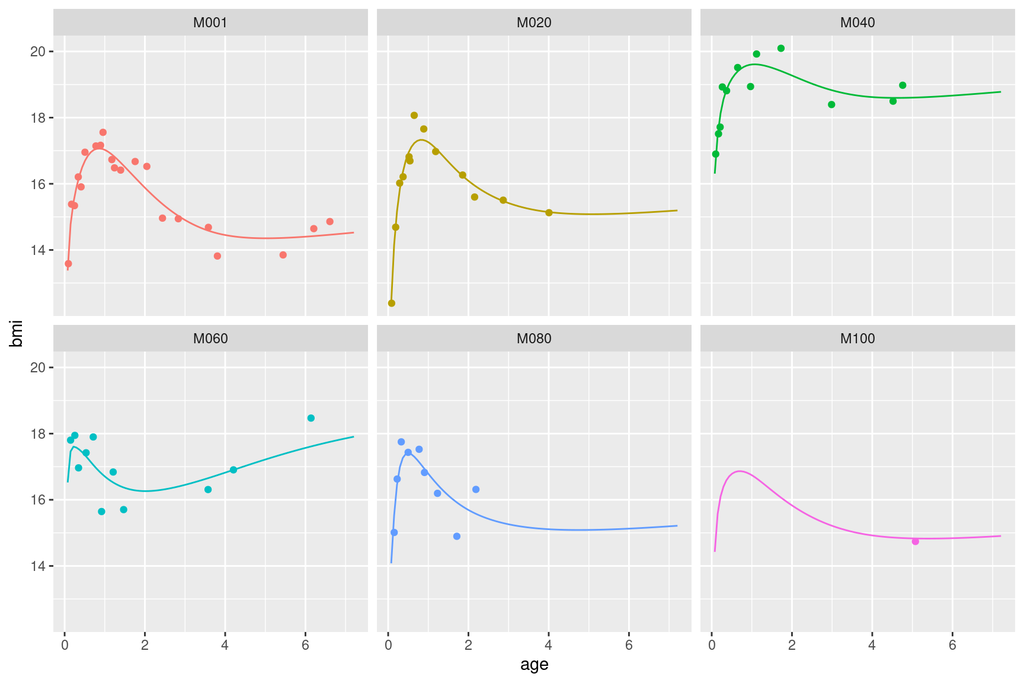

```r
## example subjects (you can choose your own)
id.selected <- levels(mbmi100$id)[seq(1, nlevels(mbmi100$id), length.out = 6)]
## subset data.frames
mbmi100.selected <- subset(mbmi100, id %in% id.selected)
subtraj.selected <- subset(subtraj, id %in% id.selected)
## plot
ggplot(data = subtraj.selected, mapping = aes(age, bmi)) +
  geom_line(data = subtraj.selected, mapping = aes(color = id), show.legend = FALSE) +
  facet_wrap(facets = vars(id)) +
  geom_point(data = mbmi100.selected, mapping = aes(color = id), show.legend = FALSE)
```

## 2.7 Predict and plot population trajectory

This is harder, as you need to know more about mgcv’s smooth construction.

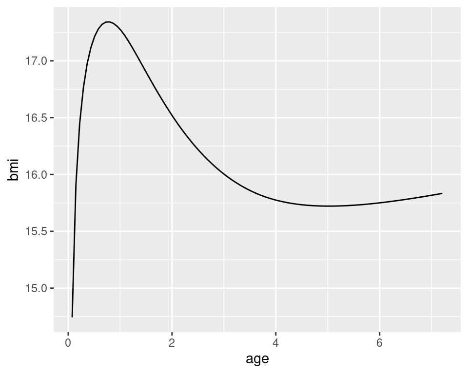

```r
## a data.frame
poptraj <- data.frame(age = age.grid, lage = log(age.grid))

## use gratia to process a single smooth function/term
spl.term <- get_smooth(fit$gam, "s(lage)")
spl.value <- eval_smooth(spl.term, model = fit$gam, data = poptraj)$data[[1]]$est

## add predicted values to data.frame
poptraj$bmi <- spl.value + fit$gam$coefficients[["(Intercept)"]]
ggplot(data = poptraj, mapping = aes(age, bmi)) + geom_line()
```

# 3 A joint model for both sex groups

```r
head(bmi100 <- getBMI100("A"))
```

```
##          age       lage      bmi   id sex
## 1 0.09329162 -2.3720250 13.58572 M001   M
## 2 0.17268363 -1.7562941 15.38245 M001   M
## 3 0.24609857 -1.4020231 15.33981 M001   M
## 4 0.34023873 -1.0781078 16.20743 M001   M
## 5 0.40999551 -0.8916091 15.90694 M001   M
## 6 0.50694408 -0.6793546 16.95482 M001   M
```

## 3.1 A general statistical model

The observation $y_{it}$ for subject $i$ (belong to group $j$) at time $t$:

$$\begin{equation*}
y_{it} = f_j(t) + r_i(t) + e_{it},
\end{equation*}$$

- $f_j(t)$, the population trajectory for group $j$;
- $r_i(t)$, the deviation of subject $i$’s trajectory from $f(t)$.

## 3.2 Model specification in mgcv

The population trajectory $f_j(t)$ is specifed as:

```r
j + s(t, by = j, bs = "ps", k = ?, m = c(2, 2))
```

- `j`, the name (to be substituted) of the population group variable; must be provided as a factor .
- `t`, the name (to be substituted) of the time variable.
- `bs`, type of spline basis; “ps” for P-splines.
- `k`, the number of basis functions used to express each random curve; for “ps”, it is the number of B-splines.
- `m`, penalty information. `c(2, 2)` for cubic B-splines penalized by 2nd order differences.

The subject-specific deviation trajectory $r_i(t)$ is specified as:

```r
s(t, i, bs = "fs", xt = "ps", k = ?, m = c(2, 1))
```

- `t`, the name (to be substituted) of the time variable.
- `i`, the name (to be substituted) of the subject ID variable; must be provided as a factor .
- `"fs"`, the proper way for setting up random curves.
- `xt` (short for “extra”), used to specify the spline basis for each random curve.
- `k`, the number of basis functions used to express each random curve; for “ps”, it is the number of B-splines.
- `m`, penalty information. `c(2, 1)` for cubic B-splines penalized by 1nd order differences.

## 3.3 Model fitting in mgcv

In this context, the mgcv model formula is:

```r
form <- bmi ~ sex + s(lage, by = sex, bs = 'ps', k = 10, m = c(2, 2)) +
  s(lage, id, bs = "fs", xt = "ps", k = 10, m = c(2, 1))
```

We fit this model using `mgcv::gamm()` or `gamm4::gamm4()`, not `mgcv::gam()` or `mgcv::bam()`.

```r
fit <- gamm(form, data = bmi100)
```

## 3.4 Covariate grids

For prediction purpose.

```r
age.grid <- seq(min(bmi100$age), max(bmi100$age), length.out = 100)
id.grid <- factor(levels(bmi100$id), levels(bmi100$id))
sex.grid <- factor(levels(bmi100$sex), levels(bmi100$sex))
```

## 3.5 Predict and plot all aubject trajectories

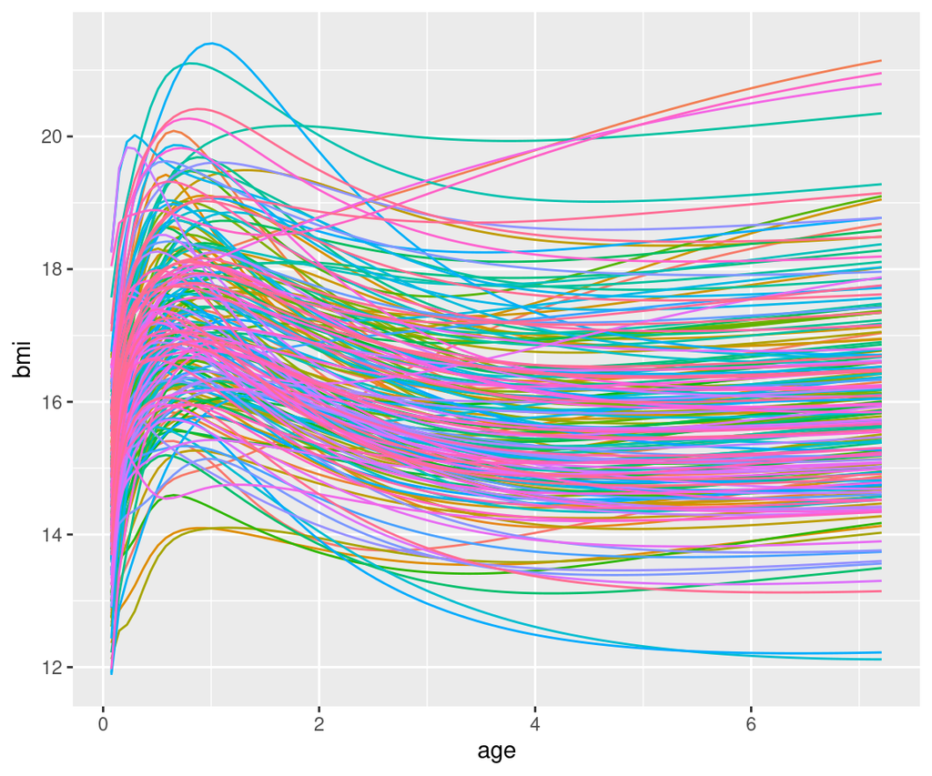

```r
subtraj <- expand.grid(age = age.grid, id = id.grid)
subtraj$sex <- substr(subtraj$id, 1, 1)  ##?
subtraj$lage <- log(age.grid)

subtraj$bmi <- predict(fit$gam, newdata = subtraj)
ggplot(data = subtraj, mapping = aes(age, bmi)) +
  geom_line(mapping = aes(color = id), show.legend = FALSE)
```

## 3.6 Plot trajectories for a few subjects

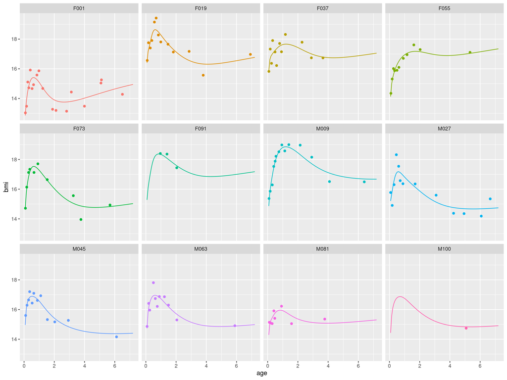

```r
id.selected <- levels(bmi100$id)[seq(1, nlevels(bmi100$id), length.out = 12)]
bmi100.selected <- subset(bmi100, id %in% id.selected)
subtraj.selected <- subset(subtraj, id %in% id.selected)
ggplot(data = subtraj.selected, mapping = aes(age, bmi)) +
  geom_line(data = subtraj.selected, mapping = aes(color = id), show.legend = FALSE) +
  facet_wrap(facets = vars(id)) +
  geom_point(data = bmi100.selected, mapping = aes(color = id), show.legend = FALSE)
```

## 3.7 Predict and plot population trajectory

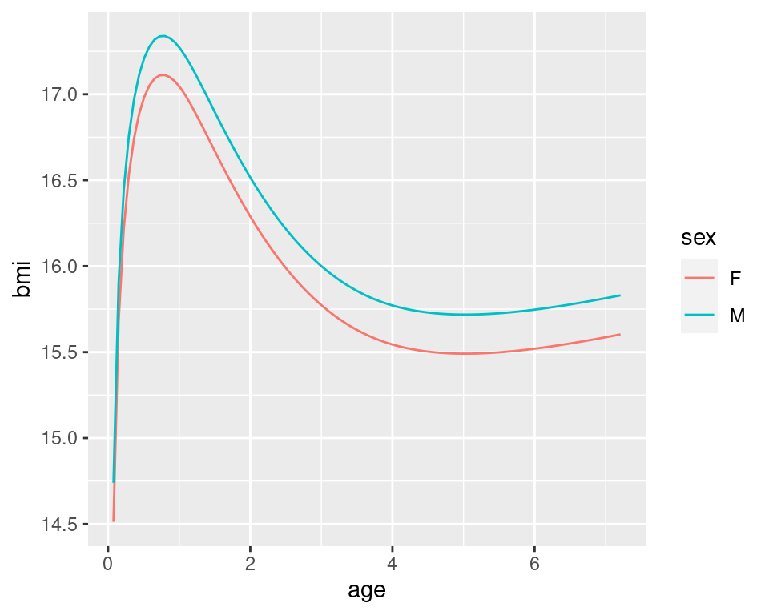

```r
poptraj.sexF <- data.frame(age = age.grid, lage = log(age.grid),
                           sex = sex.grid[1])
spl.term.sexF <- get_by_smooth(fit$gam, "s(lage)", "F")
spl.value.sexF <- eval_smooth(spl.term.sexF, model = fit$gam, data = poptraj.sexF)$data[[1]]$est
poptraj.sexF$bmi <- spl.value + fit$gam$coefficients[["(Intercept)"]]

poptraj.sexM <- data.frame(age = age.grid, lage = log(age.grid),
                           sex = sex.grid[2])
spl.term.sexM <- get_by_smooth(fit$gam, "s(lage)", "M")
spl.value.sexM <- eval_smooth(spl.term.sexM, model = fit$gam, data = poptraj.sexM)$data[[1]]$est
poptraj.sexM$bmi <- spl.value + fit$gam$coefficients[["(Intercept)"]] + fit$gam$coefficients[["sexM"]]

poptraj <- rbind(poptraj.sexF, poptraj.sexM)

ggplot(data = poptraj, mapping = aes(age, bmi)) +
  geom_line(mapping = aes(color = sex))
```

# 4 Exercises

1. Try `bmi ~ s(lage, id, bs = "fs", xt = "ps", k = 10, m = c(2, 2))`.
2. Try `bmi ~ s(lage, bs = 'ps', k = 10, m = c(2, 2)) + s(lage, id, bs = "fs", xt = "ps", k = 10, m = c(2, 2))`.